# Computational Social Science & Data Collection

Eungang Peter Choi

11/08/2019

# Outline

## Outline

1. Introduction
2. Why Collect Data?
3. Applications
4. Conclusion

# Introduction

## Things I do

- Demography
  - Fertility
  - Mortality
- Sociology
  - Inequality
  - Race
- Computational Social Science
- Social Network Analysis
- Natural Language Processing

# Why Collect Data?

## Research Question

## Does data limit the question you can ask?

Think about *auto.dta*…

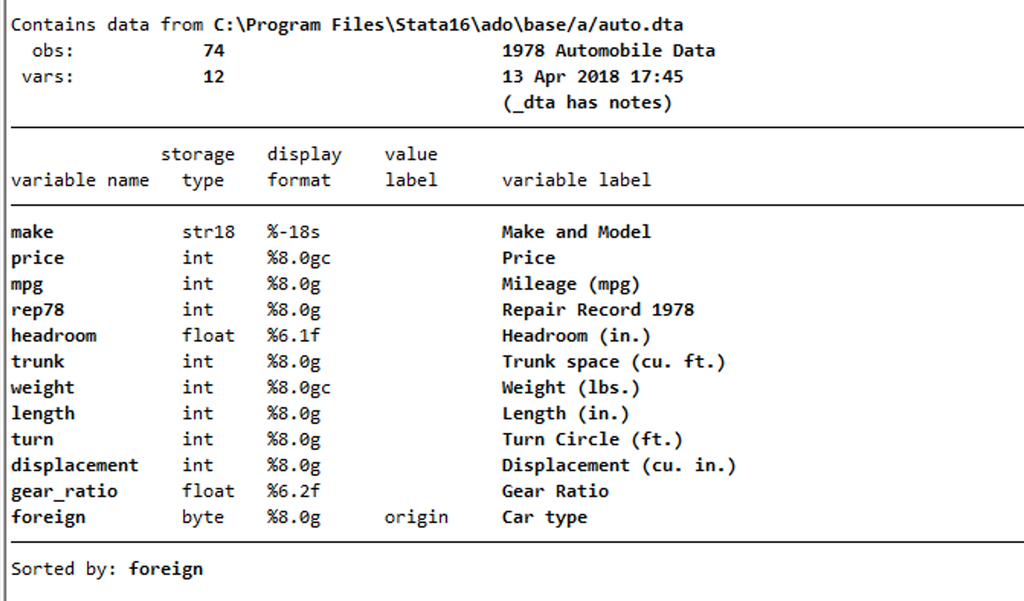

- How does price of cars change over time?
- How does preference for cars differ by age/race/ gender/place?

## Data is everywhere!

- Social Media
- [Smart Columbus](https://discovery.smartcolumbusos.com/?q=&sort=name_asc&apiAccessible=false&page=1)
- Websites/Apps

## Sephora Cry Data

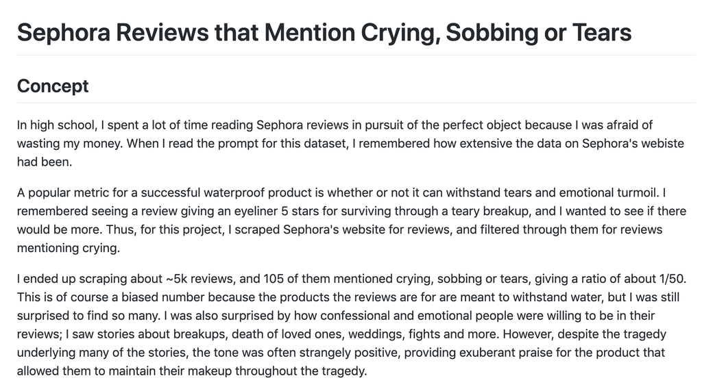

Source: Connie Ye (@crabbage_ on Twitter)

[See Sephora Cry Data](https://connie.dog/sephora/)

# Applications

## 1. Information on Social Media

Research Question: What are people’s perceptions on **Fertilty**?

## Twitter Data

- Parse Tweets with keywords relevant to fertility (e.g. babies, diapers, baby shower, breastfeeding)
- Positive/negative?
- Objective/subjective?
- Determine gender using user’s name
- Time and day of tweet
- Device info

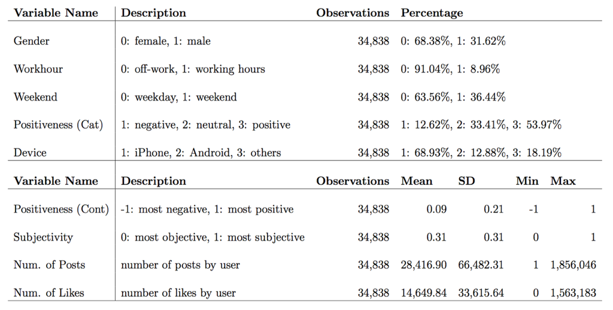

## 2. Combining Traditional Data with New Sources of Information

Research Question: How does access to transportation relate to spatial inequality?

## COTA Bus Lines

- 120+ Bus lines and 3200+ bus stops
- Matrix
- Network analysis
- Combine with food desert/income/race data

[Bus Network](https://www.eungangchoi.com/posts/asa_081019_choi/)

## 3. Using Technology to get Data

Research Question: Are user-based rating systems (e.g. Uber, Lyft, Airbnb) fair?

## Airbnb Data

- 250,000+ Airbnb listings in 28 US cities
- Host picture
- face recognition
- skin color information (RGB, HSV, YCrCb, LAB)
- Machine learning (scale 1-5)
- text analysis (NLP)

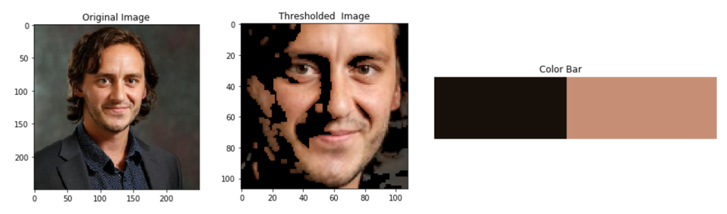

## Variables

- skin tone
- price of house
- superhost?
- number of reviews?
- expected rating based on text reviews

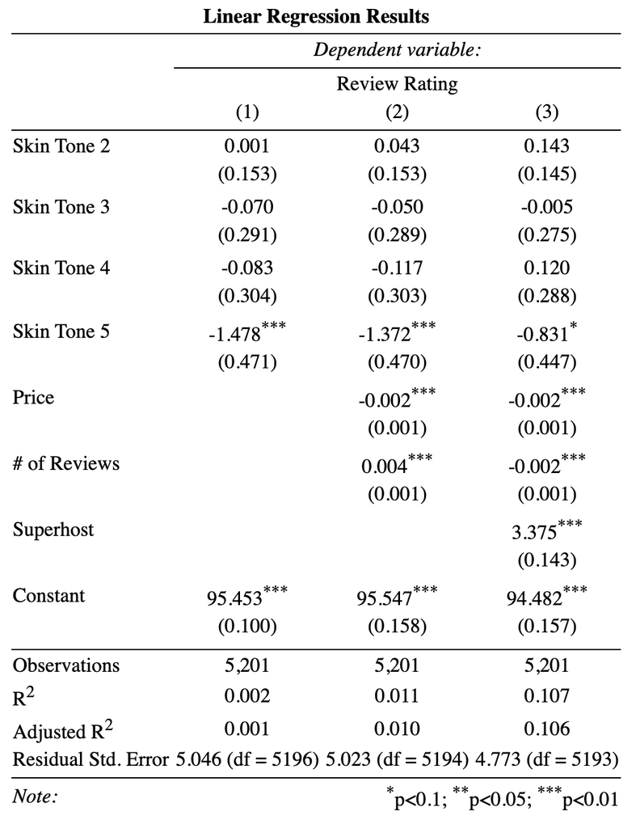

# Conclusion

## What do you want to do?

- get a job/work?
- grad school?
- Don’t let data limit your research question
- Data is everywhere!
  - self-logging
  - Websites
  - social media

## Interested?

Get upto 3 credit hours twoards your Experiential Learning Requirement -

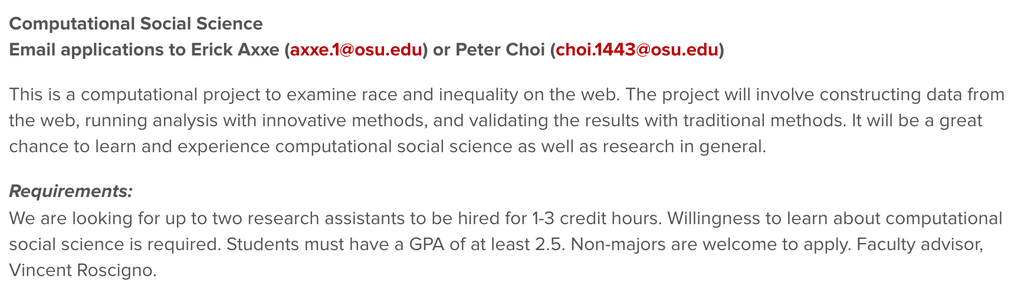

> choi.1443@osu.edu https://www.eungangchoi.com